# Project 1 - Text Mining Chess Data

Luis Calleja

September 19, 2016

In this project, the Output goal is a dataframe with the following informaiton (in order): player’s name, player’s state, total # of points, player’s pre-rating, avg pre chess rating of opponents.

```r
g<-file('/home/lechuza/Documents/CUNY/data_class/project1/tournamentinfo.txt')
raw<-readLines(g)
```

ReadLines (above) splits on line breaks; however, each player spans two lines. In order to get the desired output of one line per player, we’ll apply regex to concatenated elements and split on “-{3,}” (dashes).

```r
#raw_c<-str_c(raw[-(0:4)])
raw_c<-paste(raw[-(0:4)], collapse = '')
```

Investigate that the collapse did not result in unintended results

```r
#ouput supressed
nchar(raw_c)
g<-sapply(raw,nchar)
sum(g)
```

The lengths/number of characters are nearly the same, so we are good.

```r
raw_split<-unlist(str_split(raw_c,"-{3,}"))
```

Commence string extraction; the convenient feature is that we can do our computations at the local level, then apply it to the vector elements as a vector function

### Text extraction

We start with name.

We know that names appear in the second slot, so we could split on the pipe “|” then run the regex.

Let’s run this string split on the entire vector to determine how normalized is the data. We will run some diagnostics, ie ensure equal number of elements created from the split.

```r
spl.1<-function(x) {
  unlist(str_split(x,"\\|"))
}
te.1<-sapply(raw_split,spl.1,USE.NAMES = FALSE)
te.1<-te.1[-65]
```

```r
#output suppressed
#ensure equal number of elements for all vectors
gf<-sapply(te.1,function(x) length(unlist(x)))
any(gf!=21)
```

The above proves that each player field has 21 elements. Hence the data is normalized and can be placed in a structured object.

```r
h<-data.frame(sapply(te.1,function(x) rbind(unlist(x))),stringsAsFactors = FALSE)
```

Let’s clean up each element in the dataframe and transpose it.

```r
#works as intended
#dr<-as.character(str_trim(h[,4]))
h.1<-colwise(str_trim)(h)
#transpose the dataframe
h.t<-as.data.frame(t(h.1),stringsAsFactors = FALSE)
#convert all these factors to characters

#put column names on the dataframe...
```

We can start to build the ‘production’ dataframe. First we create one with the player’s name and state:

```r
#h.t[1:5,3]
final<-h.t[,c(2,11,3)]
names(final)<-c('name','state','total.pts')
head(final)
```

```
##                   name state total.pts
## X1            GARY HUA    ON       6.0
## X2     DAKSHESH DARURI    MI       6.0
## X3        ADITYA BAJAJ    MI       6.0
## X4 PATRICK H SCHILLING    MI       5.5
## X5          HANSHI ZUO    MI       5.5
## X6         HANSEN SONG    OH       5.0
```

Extract pre-rating from 12th column.

There are a couple of iterations on how the pre-rating appears in the data, we combine regex to mine for both with an ‘OR’ operation.

```r
#h.t[39,12]
#str_trim(unlist(str_extract_all(h.t[39,12]," ([[:digit:]]){2,} |([[:digit:]]){2,}P.+?(?=-)")))

#we'll run two operations... first the initial extract, then we'll remove all p
xtract.prerating<-function(x){
  str_trim(unlist(str_extract_all(x," ([[:digit:]]){2,} |([[:digit:]]){2,}P.+?(?=-)")))
}

j<-sapply(h.t[,12],xtract.prerating)

dig<-function(x) {unlist(str_extract_all(x,"[[:digit:]]{3,}"))}
final$pre.rating<-as.numeric(sapply(j,dig))
names(final)[1:3]<-c('name', 'state', 'total.points')
head(final)
```

```
##                   name state total.points pre.rating
## X1            GARY HUA    ON          6.0       1794
## X2     DAKSHESH DARURI    MI          6.0       1553
## X3        ADITYA BAJAJ    MI          6.0       1384
## X4 PATRICK H SCHILLING    MI          5.5       1716
## X5          HANSHI ZUO    MI          5.5       1655
## X6         HANSEN SONG    OH          5.0       1686
```

Calculate the average pre-chess rating of opponents. This requires a look-up of player number then a calculation.

Opponent ids are stored in columns [4:10] on the ‘h.t’ (raw) dataframe. I’ll need to create a function that extracts the numeric portion from each of these fields which then looks up that player’s pre-rating, and ultimately taking the mean from all of the opponents played.

First do some data exploring to ensure that null values are not present. I do this by creating a vector containing all of the opponents per player.

```r
#consider re-concatenating the columns for later application of regex
f<-str_c(h.t$V4,h.t$V5,h.t$V6,h.t$V7,h.t$V8,h.t$V9,h.t$V10,sep=" ")

#create function to extract digits
opp.f<-function(x){unlist(str_extract_all(x,"[[:digit:]]{1,}"))}
rt<-sapply(f,opp.f)#working with a list
tr<-lapply(rt,unlist)
v<-sapply(rt,length)
names(v)<-NULL
any(v!=6)
```

```
## [1] TRUE
```

We see that indeed some players play more and less than others.

```r
table(v[v!=6])
```

```
##
##  1  3  4  5  7
##  1  1  1  7 41
```

```r
#can index like this because of normalization
head(h.t[v!=6,4:10])
```

```
##       V4    V5    V6    V7    V8    V9   V10
## X1 W  39 W  21 W  18 W  14 W   7 D  12 D   4
## X2 W  63 W  58 L   4 W  17 W  16 W  20 W   7
## X3 L   8 W  61 W  25 W  21 W  11 W  13 W  12
## X4 W  23 D  28 W   2 W  26 D   5 W  19 D   1
## X5 W  45 W  37 D  12 D  13 D   4 W  14 W  17
## X6 W  34 D  29 L  11 W  35 D  10 W  27 W  21
```

```r
#ensure that no player has a null or 0 pre-rating
#anyNA(final[,4])
```

This data exploration informs us that not all players have played 6 rounds, and so the function we build must be able to handle this.

```r
#rt[1] #a list
#unlist rt, using lapply, do a lookup and calculate the mean
look<-function(x){
  k<-as.numeric(unlist(x))
  mean(final[k,4])
}
#names(d)<-NULL
final$pre.opp<-sapply(tr,look)
```

Before exporting to a csv, let’s do a visualization of the data to look for outliers.

First, we’ll plot a histogram of player pre-ratings… we’ll then compare this to a histogram of average opponent pre-ratings.

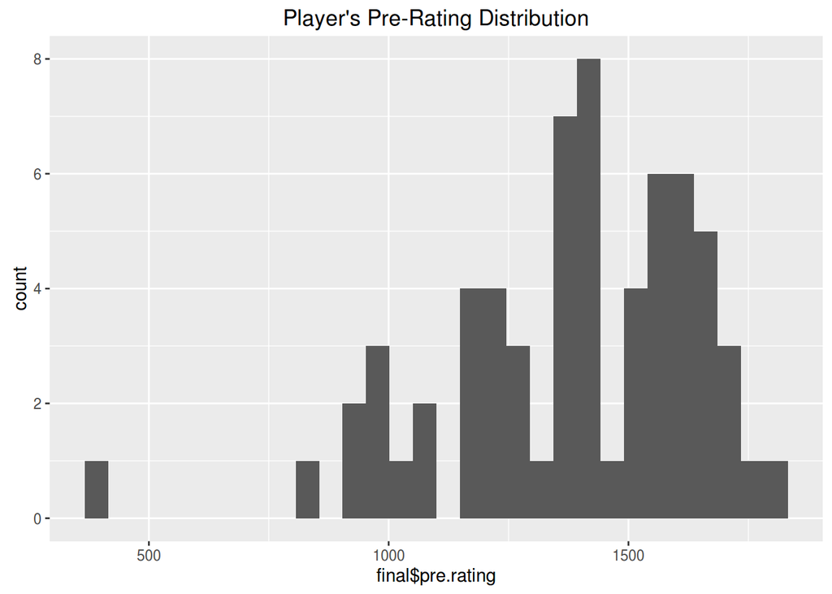

```r
#names(final)
ggplot(final, aes(final$pre.rating))+geom_histogram()+labs(title="Player's Pre-Rating Distribution")
```

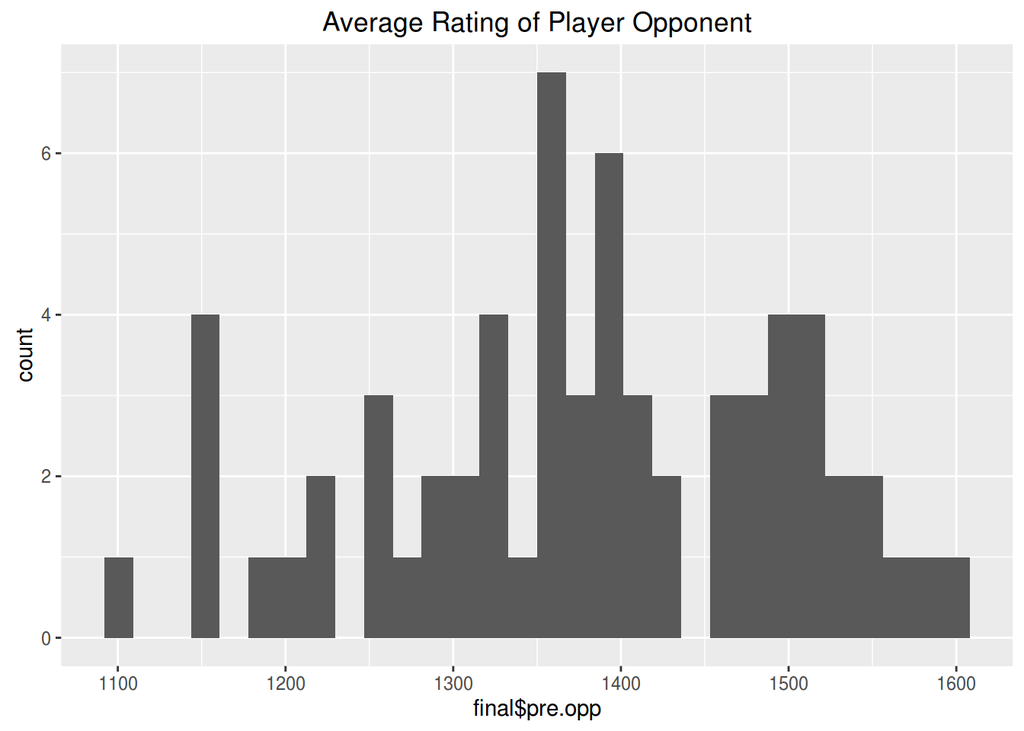

```r
ggplot(final, aes(final$pre.opp))+geom_histogram()+labs(title="Average Rating of Player Opponent")
```

Last thing… let’s check that outlier player rating < 400…

```r
final[final$pre.rating==377,]
```

```
##                         name state total.points pre.rating  pre.opp
## X46 JACOB ALEXANDER LAVALLEY    MI          3.0        377 1357.714
```

```r
h.t[46,1:12]
```

```
##     V1                       V2  V3    V4    V5    V6    V7    V8    V9
## X46 46 JACOB ALEXANDER LAVALLEY 3.0 W  35 L   7 L  27 L  50 W  64 W  43
##       V10 V11                            V12
## X46 L  23  MI 15490981 / R:  377P3 ->1076P10
```

I think we’re good: the regex extracted ratings the same way the other players’ ratings were. We confirmed using the sample on the project direction sheet.

Finally, write this out to a csv:

```r
write.csv(final,'your/directory/chess.csv')
```